# Effect of Loan Variables on The Borrower Rate and Its Impact on Other Loan Variables

## by Isaac Ayeni

## Investigation Overview

In this investigation, I aim to determine the main loan variables that the borrower rate is dependent. Also to be determined is the other variables which are dependent upon the value of the borrower rate.

## Dataset Overview

The data consists of information regarding 113,937 loans with variables including the borrower rate, loan original amount and other variables all together making up 81 variables. For the purpose of this data exploration and analysis, the number of variables have been reduced to 12 variables and the number of entries have been reduced to 84853 loan entries due to missing information on several variables.

## Distribution of Borrower Rates

The borrower rates take on values ranging from 0.04 to 0.36. The frequencies across intervals in the borrower rates appear uneven, although there is a notable jump in the frequency occuring a little over 0.3 borrower rate

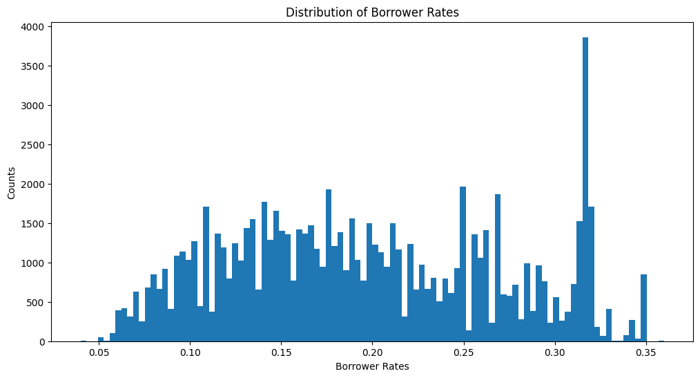

## Distribution of Estimated Loss

Estimated loss is the estimated principal loss on charge-offs. The distribution of the Estimated loss show a lot of gaps in the distribution and a significant amount of frequency spikes.

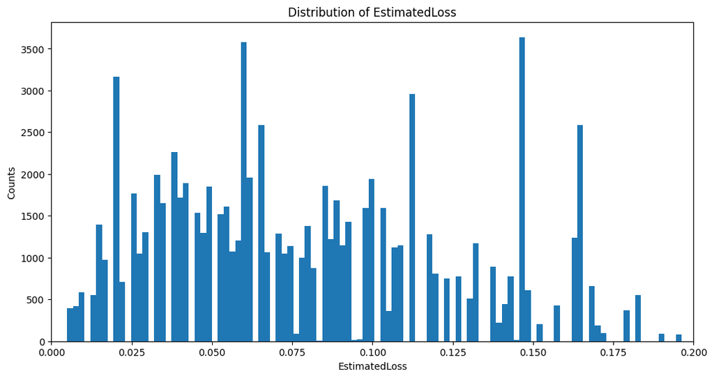